## Homework #1

## Jeremy Guinta (ID: 604882679)

## April 26, 2018

### The Sound of Gunfire, Off in the Distance

Our first dataset this week comes from a study of the causes of civil wars.[^1] The data can be read into from a csv posted online by using the following command.

```r
war <- read.csv("http://www.stat.cmu.edu/~cshalizi/uADA/15/hw/06/ch.csv", row.names = 1)
#war<-read.csv("C:/users/jguinta/desktop/ch.csv", row.names=1)

war<-as.data.table(war)
```

Every row of the data represents a combination of a country and of a five year interval â the first row is Afghanistan, 1960, really meaning Afghanistan, 1960â“1965. The variables are:

- The country name;
- The year;
- An indicator for whether a civil war began during that period: 1 indicates a civil war has begun, the code of NA means an on-going civil war, 0 means peace.
- Exports, really a measure of how dependent the countryâs economy is on com- modity exports;
- Secondary school enrollment rate for males, as a percentage;
- Annual growth rate in GDP;
- An index of the geographic concentration of the countryâs population (which would be 1 if the entire population lives in one city, and 0 if it evenly spread across the territory);
- The number of months since the countryâs last war or the end of World War II, whichever is more recent;
- The natural logarithm of the countryâs population;
- An index of social âfractionalizationâ, which tries to measure how much the country is divided along ethnic and/or religious lines;
- An index of ethnic dominance, which tries to measure how much one ethnic group runs affairs in the country.

Some of these variables are NA for some countries.

### 0

Perform some basic exploratory analysis on the data

```r
str(war)
```

```
## Classes 'data.table' and 'data.frame':   1288 obs. of  11 variables:
##  $ country          : Factor w/ 161 levels "Afghanistan",..: 1 1 1 1 1 1 1 1 2 2 ...
##  $ year             : int  1960 1965 1970 1975 1980 1985 1990 1995 1960 1965 ...
##  $ start            : int  0 0 0 1 NA NA 1 NA 1 0 ...
##  $ exports          : num  0.074 0.074 0.043 0.085 0.24 ...
##  $ schooling        : num  2 4 13 13 16 11 9 32 9 10 ...
##  $ growth           : num  NA NA NA NA NA ...
##  $ peace            : int  172 232 292 352 NA NA 3 NA 4 24 ...
##  $ concentration    : num  0.492 0.492 0.492 0.492 0.492 ...
##  $ lnpop            : num  16.1 16.2 16.3 16.5 16.6 ...
##  $ fractionalization: int  132 132 132 132 132 132 132 132 132 132 ...
##  $ dominance        : int  1 1 1 1 1 1 1 1 1 1 ...
##  - attr(*, ".internal.selfref")=<externalptr>
```

```r
summary(war)
```

```
##         country          year          start            exports
##  Afghanistan:   8   Min.   :1960   Min.   :0.00000   Min.   :0.0020
##  Algeria    :   8   1st Qu.:1969   1st Qu.:0.00000   1st Qu.:0.0515
##  Angola     :   8   Median :1978   Median :0.00000   Median :0.1090
##  Argentina  :   8   Mean   :1978   Mean   :0.06684   Mean   :0.1640
##  Australia  :   8   3rd Qu.:1986   3rd Qu.:0.00000   3rd Qu.:0.2030
##  Austria    :   8   Max.   :1995   Max.   :1.00000   Max.   :2.1390
##  (Other)    :1240                  NA's   :121       NA's   :125
##    schooling          growth             peace       concentration
##  Min.   :  0.30   Min.   :-22.0760   Min.   :  1.0   Min.   :0.0000
##  1st Qu.: 16.00   1st Qu.: -0.3135   1st Qu.:184.0   1st Qu.:0.4670
##  Median : 38.00   Median :  1.8740   Median :305.0   Median :0.5830
##  Mean   : 42.65   Mean   :  1.5631   Mean   :326.6   Mean   :0.5751
##  3rd Qu.: 66.00   3rd Qu.:  3.7222   3rd Qu.:472.0   3rd Qu.:0.7500
##  Max.   :147.00   Max.   : 14.4090   Max.   :592.0   Max.   :0.9710
##  NA's   :251      NA's   :370        NA's   :121     NA's   :160
##      lnpop       fractionalization   dominance
##  Min.   :10.62   Min.   :   4      Min.   :0.000
##  1st Qu.:14.25   1st Qu.: 171      1st Qu.:0.000
##  Median :15.48   Median : 936      Median :0.000
##  Mean   :15.35   Mean   :1784      Mean   :0.473
##  3rd Qu.:16.55   3rd Qu.:3162      3rd Qu.:1.000
##  Max.   :20.91   Max.   :6975      Max.   :1.000
##  NA's   :22      NA's   :128       NA's   :104
```

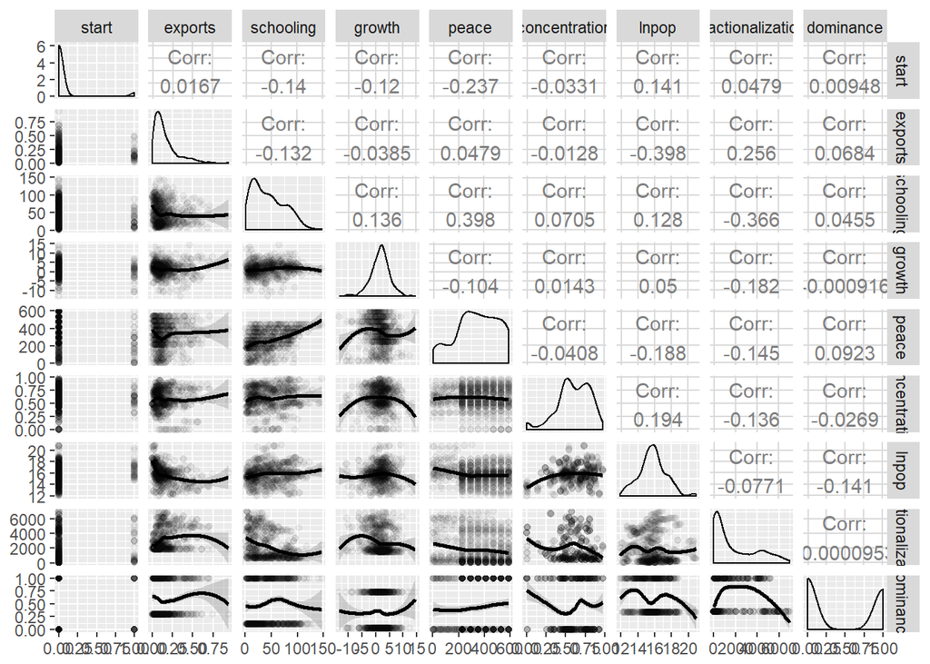

### 1

**Estimate**: Fit a logistic regression model for the start of civil war on all other variables except country and year (yes, this makes some questionable assumptions about independent observations); include a quadratic term for exports. Report the coefficients and their standard errors, together with Râs p-values. Which ones are found to be significant at the 5% level?

```r
war[, exports2:=exports^2] #adding quadratic
mod1<-glm(start~exports+exports2+schooling+growth+peace+concentration+lnpop+fractionalization+dominance, data=war, family="binomial")
mod1_tidy<-as.data.table(tidy(mod1))
mod1_tidy[, .(term, est=round(estimate,4), stderr=round(std.error,4), pval=round(statistic,4))]
```

```
##                  term      est  stderr    pval
##  1:       (Intercept) -13.0731  2.7952 -4.6769
##  2:           exports  18.9370  5.8651  3.2287
##  3:          exports2 -29.4432 11.7813 -2.4992
##  4:         schooling  -0.0316  0.0098 -3.2252
##  5:            growth  -0.1152  0.0431 -2.6753
##  6:             peace  -0.0037  0.0011 -3.3970
##  7:     concentration  -2.4870  1.0052 -2.4741
##  8:             lnpop   0.7677  0.1658  4.6318
##  9: fractionalization  -0.0002  0.0001 -2.3451
## 10:         dominance   0.6704  0.3535  1.8963
```

### 2

**Interpretation**: All parts of this question refer to the logistic regression model you just fit.

1. What is the modelâs predicted probability for a civil war in India in the period beginning 1975?

```r
ind<-war[country=="India" & year==1975]
ind
```

```
##    country year start exports schooling growth peace concentration
## 1:   India 1975     0   0.026        36  0.322   112         0.537
##       lnpop fractionalization dominance exports2
## 1: 20.23462              2937         0 0.000676
```

```r
ind0<-predict(mod1, newdata=ind, type="response")
ind0
```

```
##         1
## 0.3504199
```

What probability would it predict for a country just like India in 1975, except that its male secondary school enrollment rate was 30 points higher?

```r
ind<-war[country=="India" & year==1975]
ind[, schooling:=schooling+30]
ind
```

```
##    country year start exports schooling growth peace concentration
## 1:   India 1975     0   0.026        66  0.322   112         0.537
##       lnpop fractionalization dominance exports2
## 1: 20.23462              2937         0 0.000676
```

```r
ind1<-predict(mod1, newdata=ind, type="response")
ind1
```

```
##       1
## 0.17309
```

What probability would it predict for a country just like India in 1975, except that the ratio of commodity exports to GDP was 0.1 higher?

```r
ind<-war[country=="India" & year==1975]
ind[, exports:=exports+0.1]
ind[, exports2:=exports^2]
ind
```

```
##    country year start exports schooling growth peace concentration
## 1:   India 1975     0   0.126        36  0.322   112         0.537
##       lnpop fractionalization dominance exports2
## 1: 20.23462              2937         0 0.015876
```

```r
ind2<-predict(mod1, newdata=ind, type="response")
ind2
```

```
##         1
## 0.6961378
```

2. What is the modelâs predicted probability for a civil war in Nigeria in the period beginning 1965?

```r
nig<-war[country=="Nigeria" & year==1965]
nig
```

```
##    country year start exports schooling growth peace concentration
## 1: Nigeria 1965     1   0.123         7  1.916   232         0.539
##       lnpop fractionalization dominance exports2
## 1: 17.65479              6090         0 0.015129
```

```r
nig0<-predict(mod1, newdata=nig, type="response")
nig0
```

```
##         1
## 0.1709917
```

What probability would it predict for a country just like Nigeria in 1965, except that its male secondary school enrollment rate was 30 points higher?

```r
nig<-war[country=="Nigeria" & year==1965]
nig[, schooling:=schooling+30]
nig
```

```
##    country year start exports schooling growth peace concentration
## 1: Nigeria 1965     1   0.123        37  1.916   232         0.539
##       lnpop fractionalization dominance exports2
## 1: 17.65479              6090         0 0.015129
```

```r
nig1<-predict(mod1, newdata=nig, type="response")
nig1
```

```
##          1
## 0.07410315
```

What probability would it predict for a country just like Nigeria in 1965, except that the ratio of commodity exports to GDP was 0.1 higher?

```r
nig<-war[country=="Nigeria" & year==1965]
nig[, exports:=exports+0.1]
nig[, exports2:=exports^2]
nig
```

```
##    country year start exports schooling growth peace concentration
## 1: Nigeria 1965     1   0.223         7  1.916   232         0.539
##       lnpop fractionalization dominance exports2
## 1: 17.65479              6090         0 0.049729
```

```r
nig2<-predict(mod1, newdata=nig, type="response")
nig2
```

```
##         1
## 0.3310044
```

3. In the parts above, you changed the same predictor variables by the same amounts. If you did your calculations properly, the changes in predicted probabilities are not equal. Explain why not. (The reasons may or may not be the same for the two variables.)

```r
ind0-ind1
```

```
##         1
## 0.1773298
```

```r
nig0-nig1
```

```
##          1
## 0.09688857
```

```r
ind0-ind2
```

```
##         1
## -0.345718
```

```r
nig0-nig2
```

```
##          1
## -0.1600127
```

Even though the model does not control for country or year, linear changes to the variables will not result in an exact unit change in the predicted probabilties. This is because the link function (sigmoid) is not linear so changes to values move along the sigmoid function at different rates.

The change in predicted probabilties for the schooling variable is not the same between India and Nigeria because even though we increased the variable linearly, the link function (sigmoid) is not linear. This means that changes at different points along the sigmoid function produce different predicted results.

The same is true for growth in exports. Additionally, since we adjusted the growth in exports variable by a linear amount, we also need to adjust the squared growth in exports variable. Since this is not a linear change, we see the change in predicted probabilties between the models change at different rates.

### 3

**Confusion**: Logistic regression predicts a probability of civil war for each country and period. Suppose we want to make a definite prediction of civil war or not, that is, to classify each data point. The probability of misclassification is minimized by predicting war if the probability is â¥ 0.5, and peace otherwise.

```r
pred<-predict(mod1, war, type="response")
pred<-as.data.table(cbind(war, pred))
pred[, pred_flg:=ifelse(pred>=0.5,1,0)]
```

1. Build a 2 Ã 2 *confusion matrix* (a.k.a. âclassification tableâ or âcontigency tableâ) which counts: the number of outbreaks of civil war correctly predicted by the logistic regression; the number of civil wars not predicted by the model; the number of false predictions of civil wars; and the number of correctly predicted absences of civil wars. (Note that some entries in the table may be zero.)

```r
pred<-as.data.frame(pred)
table(pred[c("pred_flg", "start")])
```

```
##         start
## pred_flg   0   1
##        0 637  43
##        1   5   3
```

```r
pred<-as.data.table(pred)
```

This model is terrible. It rarely predicts the start of a civil war (based on on a 0.50 cutoff) at all.

2. What fraction of the logistic regressionâs predictions are incorrect, i.e. what is the misclassification rate? (Note that this is if anything too kind to the model, since itâs looking at predictions to the same training data set).

The misclassification rate for no civil war is the number of times the model predicted civil war, but there was no civil war. That rate is 0.8%. (5 divided by 642).

The misclassification rate for civil war is the number of times the model did not predict civil war, but there was a civil war. That rate is 93%. (43 divided by 46).

3. Consider a foolish (?) pundit who always predicts âno warâ. What fraction of the punditâs predictions are correct on the whole data set? What fraction are correct on data points where the logistic regression model also makes a prediction?

### 4

**Comparison**: Since this is a classification problem with only two classes, we can compare Logistic Regression right along side Discriminant Analysis. This will require some reading. (see Introduction to Statistical Learning pages 138-149)

1. Fit an Linear Discriminant Analysis (LDA) model using the same predictors that you used for your logistic regression model.

```r
war[, exports2:=exports^2] #adding quadratic
mod2<-lda(start~exports+exports2+schooling+growth+peace+concentration+lnpop+fractionalization+dominance, data=war)
pred_lda<-predict(mod2, war, method="predictive")

pred_lda_class<-as.data.frame(pred_lda[[1]])
names(pred_lda_class)<-c("class")
pred_lda_post<-as.data.frame(pred_lda[[2]])
names(pred_lda_post)<-c("no_civil", "civil")
pred_lda_x<-as.data.frame(pred_lda[[3]])

pred_lda<-as.data.table(cbind(pred_lda_class, pred_lda_post, pred_lda_x))
pred_lda<-cbind(war, pred_lda)
```

What is the training misclassification rate?

The misclassification rate would be when the model predicted civil war when no civil war occurred or when the model did not predict a civil war, but a civil war did occur. Using a 0.50 cutoff, the confusion matrix for LDA is:

```r
pred_lda<-as.data.frame(pred_lda)
table(pred_lda[c("class", "start")])
```

```
##      start
## class   0   1
##     0 637  42
##     1   5   4
```

```r
pred_lda<-as.data.table(pred_lda)
```

The misclassification rate for no civil war is the number of times the model predicted civil war, but there was no civil war. That rate is 0.8%. (5 divided by 642).

The misclassification rate for civil war is the number of times the model did not predict civil war, but there was a civil war. That rate is 91%. (42 divided by 46).

2. Fit a Quadratic Discriminat Analysis (QDA) model using the very same predictors. What is the training misclassification rate?

```r
war[, exports2:=exports^2] #adding quadratic
mod3<-qda(start~exports+exports2+schooling+growth+peace+concentration+lnpop+fractionalization+dominance, data=war)
pred_qda<-predict(mod3, war, method="predictive")

pred_qda_class<-as.data.frame(pred_qda[[1]])
names(pred_qda_class)<-c("class")
pred_qda_post<-as.data.frame(pred_qda[[2]])
names(pred_qda_post)<-c("no_civil", "civil")

pred_qda<-as.data.table(cbind(pred_qda_class, pred_qda_post))
pred_qda<-cbind(war, pred_qda)
```

```r
pred_qda<-as.data.frame(pred_qda)
table(pred_qda[c("class", "start")])
```

```
##      start
## class   0   1
##     0  70   0
##     1 572  46
```

```r
pred_qda<-as.data.table(pred_qda)
```

The misclassification rate for no civil war is the number of times the model predicted civil war, but there was no civil war. That rate is 89%. (572 divided by 642).

The misclassification rate for civil war is the number of times the model did not predict civil war, but there was a civil war. That rate is 0%. (0 divided by 46).

3. How does the prediction accuracy of the three models compare? Why do you think this is?

All of these models are terrible at definitely predicting a civil war using a 0.50 cutoff.

1. The GLM model rarely predicts a civil war correct.
2. The LDA model gets it right in a couple of instances, but it is more likely to predict no civil war when one did take place.
3. The QDA model completely misses the mark and calls nearly everything a civil war.

There are likely four main reasons for the poor performance.

#### 1. Civil war is extremely rare.

The models are having a difficult time identifying any of the patterns in the data and indicate a civil war. For example:

```r
war[exports >=0.500 & exports<=0.510 & schooling >= 60 & schooling<=65,.(country, year, start, exports, schooling, growth, peace, concentration, lnpop, fractionalization, dominance)]
```

```
##    country year start exports schooling growth peace concentration
## 1:   Congo 1990     0   0.508        62 -3.974   532         0.782
## 2:   Congo 1995     1   0.505        62 -3.233   592         0.804
##       lnpop fractionalization dominance
## 1: 14.63793              4092         1
## 2: 14.78363              4092         1
```

The Congo in 1990 did not have a civil war, but it did in 1995. The variables have very similar values between the 1990 and 1995 observations but very different outcomes.

Additionally, Burundi had multiple civil wars and also had similar conditions.

```r
war[country=="Burundi",.(country, year, start, exports, schooling, growth, peace, concentration, lnpop, fractionalization, dominance)][order(start, year)]
```

```
##    country year start exports schooling growth peace concentration
## 1: Burundi 1960     0   0.078         1     NA   172         0.308
## 2: Burundi 1965     0   0.078         2 -9.906   232         0.308
## 3: Burundi 1975     0   0.073         4  5.414    12         0.308
## 4: Burundi 1980     0   0.069         4  1.425    72         0.308
## 5: Burundi 1970     1   0.098         3 -2.685   292         0.308
## 6: Burundi 1985     1   0.095         5  1.868   132         0.308
## 7: Burundi 1990     1   0.064         7  0.854    16         0.308
## 8: Burundi 1995    NA   0.064         8 -4.784    NA         0.291
##       lnpop fractionalization dominance
## 1: 14.89426               240         0
## 2: 14.98272               240         0
## 3: 15.11842               210         0
## 4: 15.23379               180         0
## 5: 15.07227               240         0
## 6: 15.37366               180         0
## 7: 15.51789               180         0
## 8: 15.65033               180         0
```

As the country flipped flop to and from civil war, many of the captured variables did not change.

#### 2. The data has many missing observations.

Nearly half the data gets thrown out based on incomplete cases for the model specification. Furthermore, there are missing values for the civil war start variable.

#### 3. The variables captured may not be useful.

This is not possible to test using the data that is available, but it could be feasible that the there is data that better captures instances of civil war. Since we do not have that data, our model is destined to be poor.

### 4. A 0.50 cutoff for determining a civil war is a poor choice.

The rate of civil war is so small that a cutoff of 0.50 for the model to accurately predict if a civil war is going to happen appears to be too stringent. The model may be more useful to determine if the rate of civil war is increasing (or decreasing) over time.

### 5

**ROC**: Construct an ROC curve for all three of your models. Plot the ROC curves of all three models on the same plot.

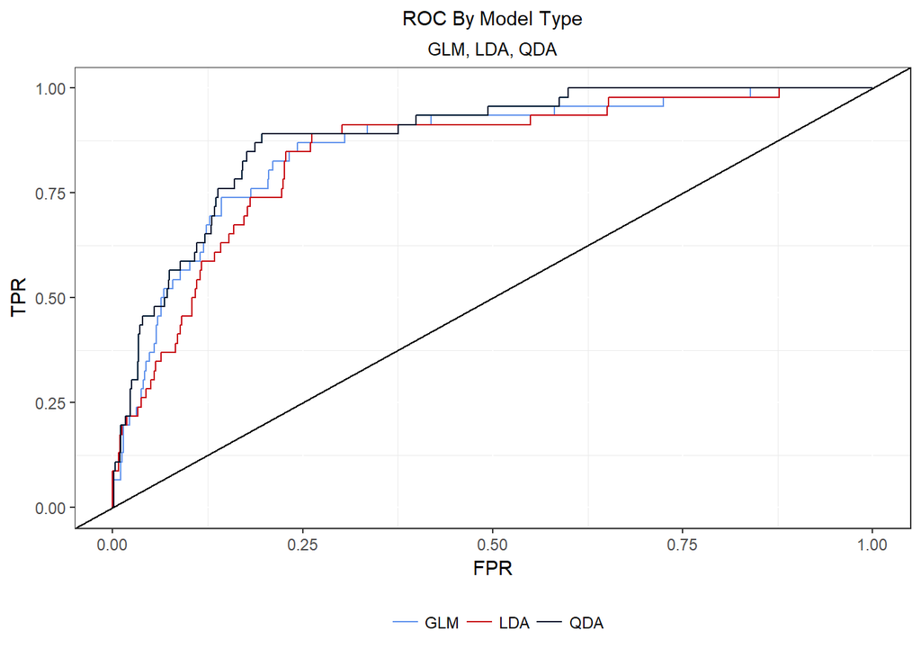

```r
#Build ROC Curve Characteristics

#GLM
prob1<-pred[, .(prob1=pred)]
pred1<-prediction(prob1, war$start)
pref1 <- performance(pred1, measure = "tpr", x.measure = "fpr")
tpr1<-as.vector(pref1@x.values)
fpr1<-as.vector(pref1@y.values)
pref1<-cbind(fpr1[[1]], tpr1[[1]])
pref1<-as.data.table(pref1)
pref1[, Type:="GLM"]

#LDA
prob2<-pred_lda[, .(prob2=civil)]
pred2<-prediction(prob2, war$start)
pref2 <- performance(pred2, measure = "tpr", x.measure = "fpr")
tpr2<-as.vector(pref2@x.values)
fpr2<-as.vector(pref2@y.values)
pref2<-cbind(fpr2[[1]], tpr2[[1]])
pref2<-as.data.table(pref2)
pref2[, Type:="LDA"]


#QDA
prob3<-pred_qda[, .(prob3=civil)]
pred3<-prediction(prob3, war$start)
pref3 <- performance(pred3, measure = "tpr", x.measure = "fpr")
tpr3<-as.vector(pref3@x.values)
fpr3<-as.vector(pref3@y.values)
pref3<-cbind(fpr3[[1]], tpr3[[1]])
pref3<-as.data.table(pref3)
pref3[, Type:="QDA"]

roc<-as.data.frame(rbind(pref1, pref2, pref3))
names(roc)<-c("TPR", "FPR", "Type")
roc<-as.data.table(roc)
roc[, Type:=as.factor(Type)]

ggplot(roc, aes(x=FPR, y=TPR, color=Type, group=Type))+geom_line() +
  theme_bw() + out_theme + scale_color_manual(values=color_scheme)+
  theme(legend.position="bottom", legend.title=element_blank()) +
  theme(plot.title = element_text(hjust = 0.5)) +
    theme(plot.subtitle = element_text(hjust = 0.5)) +
  labs(title=c("ROC By Model Type"), subtitle=c("GLM, LDA, QDA"))+
  geom_abline(intercept=0, slope=1)
```

```r
#GLM AUC
auc_pref1 <- performance(pred1, measure = "auc")
auc_pref1 <- auc_pref1@y.values[[1]]
auc_pref1
```

```
## [1] 0.8597792
```

```r
#LDA AUC
auc_pref2 <- performance(pred2, measure = "auc")
auc_pref2 <- auc_pref2@y.values[[1]]
auc_pref2
```

```
## [1] 0.8432548
```

```r
#QDA AUC
auc_pref3 <- performance(pred3, measure = "auc")
auc_pref3 <- auc_pref3@y.values[[1]]
auc_pref3
```

```
## [1] 0.8834485
```

Based on the AUC measure, the QDA model performs slightly better than the GLM and LDA models. These AUC measurements are actually considerably better than expected based on the confusion matrix results.

### 6

Fit a logistic regression using `y` as the response with x1 and x2 as indepedent variables. Does anything strange happen? Explain why

```r
y<- c(0,0,0,0,1,1,1,1)
x1<-c(1,2,3,3,5,6,10,11)
x2<-c(3,2,-1,-1,2,4,1,0)

glm1<-glm(y~x1+x2, family="binomial")
summary(glm1)
```

```
##
## Call:
## glm(formula = y ~ x1 + x2, family = "binomial")
##
## Deviance Residuals:
##             1              2              3              4              5
## -0.0000000211  -0.0000140437  -0.0000025217  -0.0000025217   0.0000156396
##             6              7              8
##  0.0000000211   0.0000000211   0.0000000211
##
## Coefficients:
##               Estimate Std. Error z value Pr(>|z|)
## (Intercept)    -66.098 183471.722   0.000        1
## x1              15.288  27362.843   0.001        1
## x2               6.241  81543.720   0.000        1
##
## (Dispersion parameter for binomial family taken to be 1)
##
##     Null deviance: 11.09035488895912  on 7  degrees of freedom
## Residual deviance:  0.00000000045454  on 5  degrees of freedom
## AIC: 6
##
## Number of Fisher Scoring iterations: 24
```

[^1]: Based on an exercise of Cosmo Shalizi’s that uses data from Collier, Paul and Anke Hoeffler (2004). *Greed and Grievance in Civil War.* Oxford Economic Papers, 56: 563â“595. URL: http://economics.ouls.ox.ac.uk/12055/1/2002-01text.pdf.